# Fallstudie Tips

Manfred Brill

# Der Datensatz Tips

Der Datensatz enthält Angaben über Trinkgelder in einem US-amerikanischen Familienrestaurant aus den neunziger Jahren. Ursprünglich stammen die Daten aus (Bryant and Smith 2003). Der Datensatz wird in vielen Büchern zur Statistik und Datenanalyse. Die vorliegende Darstellung folgt (Swayne 2007) und (Martin Theus 2009), die Daten stammen von der Website zu (Swayne 2007).

Die Daten liegen im csv-Format vor. Wir lesen die Daten mit der Funktion *read_csv* aus dem Package *readr* ein. Da wir noch weitere Funktionen wie ggplot verwenden laden wir im Setup das komplette Package *tidyverse*.

```r
daten <- read_csv("data/tips.csv")
kable(head(daten), align="l",
      caption="Tabelle 1: Die ersten Werte im Datensatz Tips") %>%
      kable_styling(bootstrap_options = c("striped", "condensed"),
                full_width = T,
                position = "center")
```

Tabelle 1: Die ersten Werte im Datensatz Tips

| obs | totbill | tip | sex | smoker | day | time | size |
| --- | --- | --- | --- | --- | --- | --- | --- |
| 1 | 17.0 | 1.01 | F | No | Sun | Night | 2 |
| 2 | 10.3 | 1.66 | M | No | Sun | Night | 3 |
| 3 | 21.0 | 3.50 | M | No | Sun | Night | 3 |
| 4 | 23.7 | 3.31 | M | No | Sun | Night | 2 |
| 5 | 24.6 | 3.61 | F | No | Sun | Night | 4 |
| 6 | 25.3 | 4.71 | M | No | Sun | Night | 4 |

Wir verändern die Überschriften der einzelnen Spalten zu deutschen Begriffen. Man könnte auch überlegen dien Dollar-Beträgen in Euro umzurechnen. Darauf verzichten wir aber, da wir das in Abhängigkeit vom Wechselkurs machen müssten.

Anschließend machen wir die Spalten, die Character-Werte enthalten zu einem *factor*. Das hätten wir schon beim Einlesen machen können, aber so können wir noch gleich die entsprechenden Funktionen sehen und wir sehen ein Beispiel für diesen speziellen Datentyp. Und wir lassen die erste Spalte, die nichts anderes als eine Nummerierung der Zeilen enthält, einfach weg.

```r
# Spalten mit deutschen Überschriften
daten <- daten %>%
  rename(
    Rechnung = totbill,
    Trinkgeld = tip,
    Geschlecht = sex,
    Wochentag = day,
    Raucher = smoker,
    Tageszeit = time,
    Anzahl = size
    )

daten$Geschlecht <- factor(daten$Geschlecht)
levels(daten$Geschlecht) <- c("Frau", "Mann")

daten$Tageszeit <- factor(daten$Tageszeit)
levels(daten$Tageszeit) <- c("Nachmittag", "Abend")

daten$Wochentag <- factor(daten$Wochentag)
levels(daten$Wochentag) <- c("Freitag", "Samstag", "Sonntag", "Donnerstag")
fct_relevel(daten$Wochentag, "Donnerstag")
```

[output not shown]

[output cut: 47 more lines]

```r
daten$Raucher <- factor(daten$Raucher)
levels(daten$Raucher) <- c("Nein", "Ja")

# Erste Spalte auslassen, die Nummerierung hat keine Information
daten <- daten %>%
  select(Rechnung:Anzahl)

kable(head(daten), align="l",
      caption="Tabelle 2: Die ersten Werte im Datensatz tips mit veränderten Überschriften") %>%
      kable_styling(bootstrap_options = c("striped", "condensed"),
                full_width = T,
                position = "center")
```

Tabelle 2: Die ersten Werte im Datensatz tips mit veränderten Überschriften

| Rechnung | Trinkgeld | Geschlecht | Raucher | Wochentag | Tageszeit | Anzahl |
| --- | --- | --- | --- | --- | --- | --- |
| 17.0 | 1.01 | Frau | Nein | Sonntag | Abend | 2 |
| 10.3 | 1.66 | Mann | Nein | Sonntag | Abend | 3 |
| 21.0 | 3.50 | Mann | Nein | Sonntag | Abend | 3 |
| 23.7 | 3.31 | Mann | Nein | Sonntag | Abend | 2 |
| 24.6 | 3.61 | Frau | Nein | Sonntag | Abend | 4 |
| 25.3 | 4.71 | Mann | Nein | Sonntag | Abend | 4 |

Wir könnten auch das Merkmal *Anzahl* zum Faktor machen, worauf aber verzichtet wird. Sollte dieses Merkmal als Faktor benötigt werden, beispielsweise in Box-Plots, dann verwenden wir *factor(Anzahl)*.

# Statistische Parameter

Wir können die Parameter aus der beschreibenden Statistik verwenden, um die vorliegenden Daten zu charakterisieren. Dazu könnten wir einfach die Funktion *summary* aus R verwenden. Aber um eine bessere Ausgabe zu erhalten verwenden die *count* und *summarise* aus *tidyverse*. Dadurch erzeugen wir neue tibbles, die wir wieder mit *kable* ausgeben können.

```r
sex.count <- daten %>%
  count(Geschlecht)

kable(sex.count, align="l",
      caption="Tabelle 3: Absolute Häufigkeiten des Merkmals Geschlecht") %>%
      kable_styling(bootstrap_options = c("striped", "condensed"),
                full_width = T,
                position = "center")
```

Tabelle 3: Absolute Häufigkeiten des Merkmals Geschlecht

| Geschlecht | n |
| --- | --- |
| Frau | 87 |
| Mann | 157 |

```r
day.count <- daten %>%
  count(Wochentag)

kable(day.count, align="l",
      caption="Tabelle 4: Verteilung der Rechnungen auf die Wochentage") %>%
      kable_styling(bootstrap_options = c("striped", "condensed"),
                full_width = T,
                position = "center")
```

Tabelle 4: Verteilung der Rechnungen auf die Wochentage

| Wochentag | n |
| --- | --- |
| Freitag | 19 |
| Samstag | 87 |
| Sonntag | 76 |
| Donnerstag | 62 |

```r
time.count <- daten %>%
  count(Tageszeit)

kable(time.count, align="l",
      caption="Tabelle 5: Verteilung der Gäste auf die Tageszeit") %>%
      kable_styling(bootstrap_options = c("striped", "condensed"),
                full_width = T,
                position = "center")
```

Tabelle 5: Verteilung der Gäste auf die Tageszeit

| Tageszeit | n |
| --- | --- |
| Nachmittag | 68 |
| Abend | 176 |

```r
smoker.count <- daten %>%
  count(Raucher)

kable(smoker.count, align="l",
      caption="Tabelle 6: Absolute Häufigkeiten des Merkmals Raucher") %>%
      kable_styling(bootstrap_options = c("striped", "condensed"),
                full_width = T,
                position = "center")
```

Tabelle 6: Absolute Häufigkeiten des Merkmals Raucher

| Raucher | n |
| --- | --- |
| Nein | 151 |
| Ja | 93 |

```r
bill.summary <- daten %>%
  summarize(
    Minimum = min(Rechnung),
    Maximum = max(Rechnung),
    Mittelwert = mean(Rechnung),
    Standardabweichung = sd(Rechnung),
    Q1 = quantile(Rechnung, 0.25),
    Median = median(Rechnung),
    Q3 = quantile(Rechnung, 0.75)
  )

kable(bill.summary, align="l",
      caption="Tabelle 7: Statistische Parameter für die Rechnungshöhe (in US-Dollar)") %>%
      kable_styling(bootstrap_options = c("striped", "condensed"),
                full_width = T,
                position = "center")
```

Tabelle 7: Statistische Parameter für die Rechnungshöhe (in US-Dollar)

| Minimum | Maximum | Mittelwert | Standardabweichung | Q1 | Median | Q3 |
| --- | --- | --- | --- | --- | --- | --- |
| 3.07 | 50.8 | 19.8 | 8.9 | 13.3 | 17.8 | 24.1 |

```r
tips.summary <- daten %>%
  summarize(
    Minimum = min(Trinkgeld),
    Maximum = max(Trinkgeld),
    Mittelwert = mean(Trinkgeld),
    Standardabweichung = sd(Trinkgeld),
    Q1 = quantile(Trinkgeld, 0.25),
    Median = median(Trinkgeld),
    Q3 = quantile(Trinkgeld, 0.75)
  )

kable(tips.summary, align="l",
      caption="Tabelle 8: Statistische Parameter für die Höhe des Trinkgelds (in US-Dollar)") %>%
      kable_styling(bootstrap_options = c("striped", "condensed"),
                full_width = T,
                position = "center")
```

Tabelle 8: Statistische Parameter für die Höhe des Trinkgelds (in US-Dollar)

| Minimum | Maximum | Mittelwert | Standardabweichung | Q1 | Median | Q3 |
| --- | --- | --- | --- | --- | --- | --- |
| 1 | 10 | 3 | 1.38 | 2 | 2.9 | 3.56 |

Da wir Modelle und Vorhersagen berechnen möchten macht es Sinn die verschiedenen Zusammenhangsmaße aus der Statistik zu berechnen. Dabei beschränken wir uns auf die numerischen Merkmale und berechnen die Korrelationen nach Kendall, Spearman und Pearson. Deshalb berechnen wir mit *select* ein weiteres tibble, das wir als Argument an die Funktion *cor* übergeben.

```r
corPrep <- daten %>%
  select(Anzahl, Rechnung, Trinkgeld)

cor(corPrep, method="kendall")
```

```
          Anzahl Rechnung Trinkgeld
Anzahl     1.000    0.484     0.378
Rechnung   0.484    1.000     0.517
Trinkgeld  0.378    0.517     1.000
```

```r
cor(corPrep, method="spearman")
```

```
          Anzahl Rechnung Trinkgeld
Anzahl     1.000    0.605     0.468
Rechnung   0.605    1.000     0.679
Trinkgeld  0.468    0.679     1.000
```

```r
cor(corPrep, method="pearson")
```

```
          Anzahl Rechnung Trinkgeld
Anzahl     1.000    0.598     0.489
Rechnung   0.598    1.000     0.676
Trinkgeld  0.489    0.676     1.000
```

Alle Parameter zeigen einen relativ großen Zusammenhang zwischen den drei numerischen Merkmalen. Dass der Zusammenhang zwischen Rechnungshöhe und Trinkgeld stark ist überrascht nicht. Auch die Anzahl der Gäste am Tisch beeinflusst natürlich die Höhe der Rechnung und das Trinkgeld.

Mit Hilfe des Kontingenzkoeffizienten können wir auch die qualitativen Merkmale in diese Analyse einbeziehen. Dazu nutzen wir die Funktion *ContCoef* aus dem Package *DescTools*. Wir beginnen mit den bereits betrachteten Merkmalen.

```r
cont.AnTip <- ContCoef(x = daten$Anzahl, y = daten$Trinkgeld, correct=TRUE)
cont.AnBill <- ContCoef(x = daten$Anzahl, y = daten$Rechnung, correct=TRUE)

cont.SexTip <- ContCoef(x = daten$Geschlecht, y = daten$Trinkgeld, correct=TRUE)
cont.TageszeitTip <- ContCoef(x = daten$Tageszeit, y = daten$Trinkgeld, correct=TRUE)
cont.TagTip <- ContCoef(x = daten$Wochentag, y = daten$Trinkgeld, correct=TRUE)
cont.RaucherTip <- ContCoef(x = daten$Raucher, y = daten$Trinkgeld, correct=TRUE)
```

Der korrigierte Kontingenzkoeffizient zwischen der Anzahl der Gäste und der Höhe des Trinkgelds ist durch 0.938 gegeben und deutet auf einen hohen Zusammenhang hin. Der korrigierte Kontingenzkoeffizient zwischen Anzahl der Gäste und Rechnungshöhe ist durch 0.991 gegeben, auch hier ein Hinweis auf einen starken Zusammenhang. Wir berechnen die weiteren korrigierten Kontingenzkoeffizienten und geben die Ergebnisse in der folgenden Tabelle aus:

| Merkmal | Korrigierter Kontingenzkoeffizienten |
| --- | --- |
| Geschlecht | 0.808 |
| Tageszeit | 0.785 |
| Wochentag | 0.875 |
| Raucher/Nichtraucher | 0.794 |

# Visualisierungen

wir erstellen visualisierungen der Merkmale im Datensatz mit ggplot. Eine ganze Reihe dieser Abbildungen wird mit *ggsave* auch gespeichert. Die Aufrufe von *ggsave* gehen davon aus, dass es im Verzeichnis in dem diese Datei liegt ein Unterverzeichnis *images* existiert, in dem die Bitmaps gesammelt werden.

## Balkendiagramme

Wir erzeugen Balkendiagramme, um einen Überblick über den Datensatz zu bekommen. Dabei erzeugen wir eine Grundform und fügen sukzessive Features hinzu.

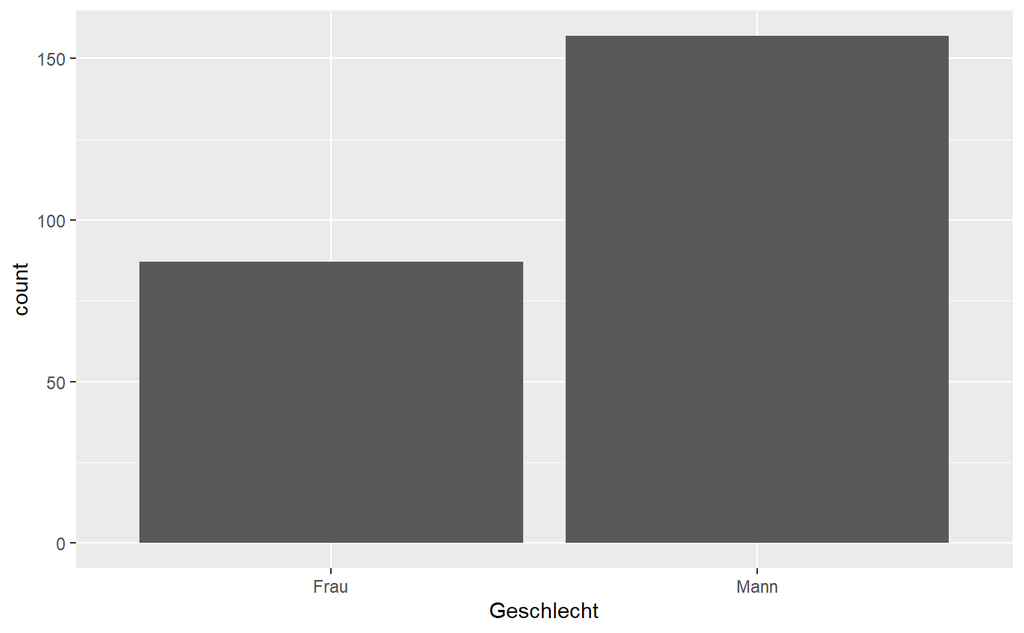

```r
balken <- ggplot(daten) +
  geom_bar(mapping=aes(x=Geschlecht))

# Keine Farben
balken
```

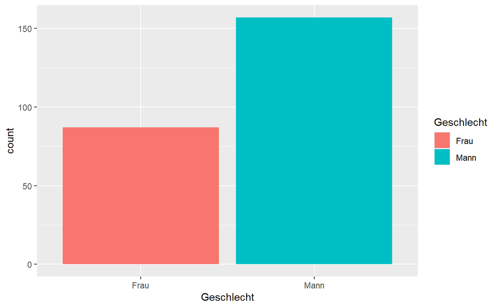

```r
balken <- ggplot(daten) +
  geom_bar(mapping=aes(x=Geschlecht, fill=Geschlecht))

# Mit Default-Farben von ggplot
balken
```

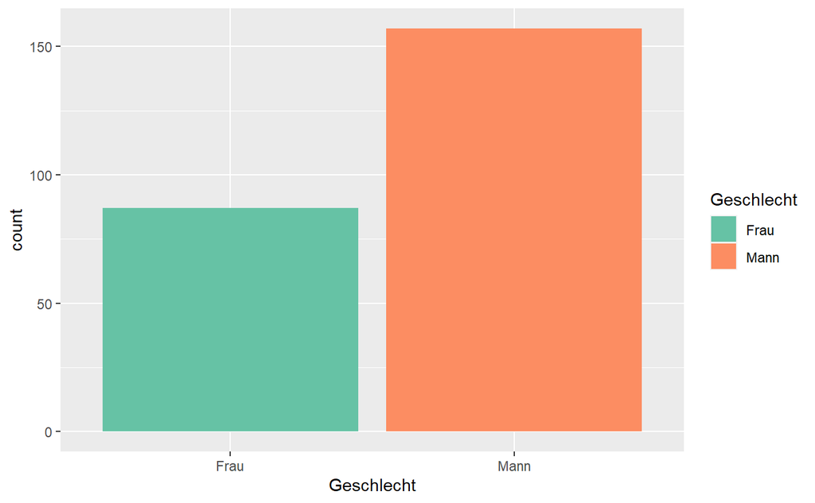

```r
# Mit Farben aus der Skala Set2 aus ColorBrewer
balken +
  scale_fill_brewer(palette="Set2")
```

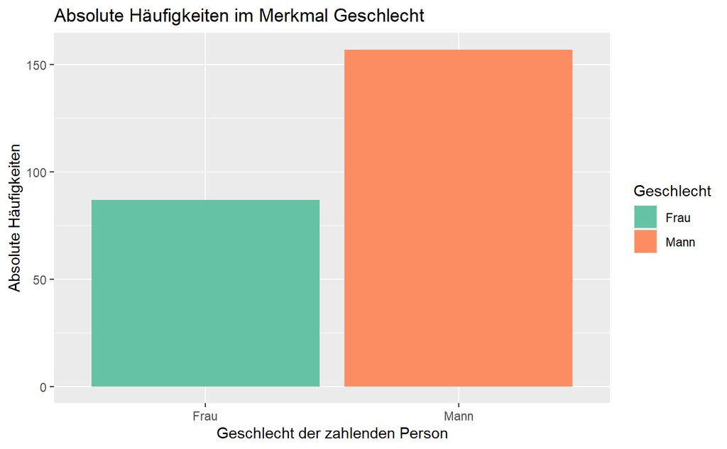

```r
# Mit Farben aus der Palette Set2 aus ColorBrewer
# und Beschriftung
balken +
  scale_fill_brewer(palette="Set2") +
  labs(
    title="Absolute Häufigkeiten im Merkmal Geschlecht",
    x="Geschlecht der zahlenden Person",
    y="Absolute Häufigkeiten"
  )
```

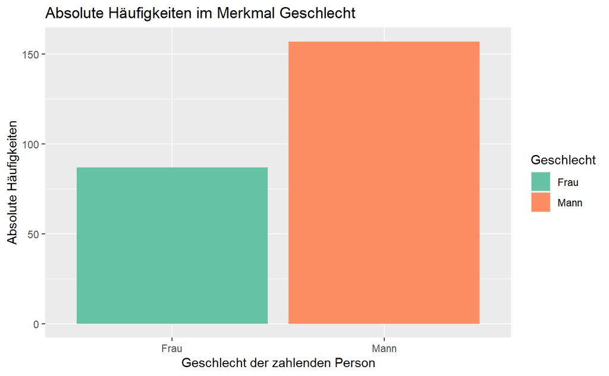

```r
# Mit Titel und Beschriftung und Legendentitel
balken +
  scale_fill_brewer(palette="Set2") +
  labs(
    title="Absolute Häufigkeiten im Merkmal Geschlecht",
    x="Geschlecht der zahlenden Person",
    y="Absolute Häufigkeiten"
  )  +
 guides(fill=guide_legend(title="Geschlecht"))
```

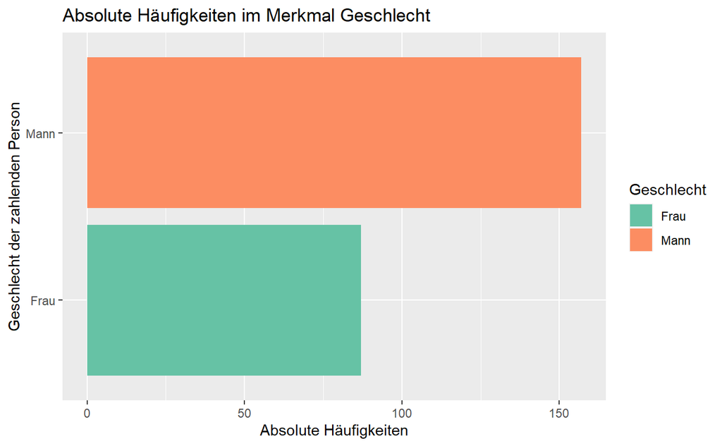

```r
balken +
  scale_fill_brewer(palette="Set2") +
  labs(
    title="Absolute Häufigkeiten im Merkmal Geschlecht",
    x="Geschlecht der zahlenden Person",
    y="Absolute Häufigkeiten"
  )  +
 guides(fill=guide_legend(title="Geschlecht")) +
 coord_flip()

 # Dieses Bild speichern wir ab
 ggsave(filename="tipsBarSex.png", plot=last_plot(),
       device="png",
       path="images/",
       width=16, height=9, units="cm")
```

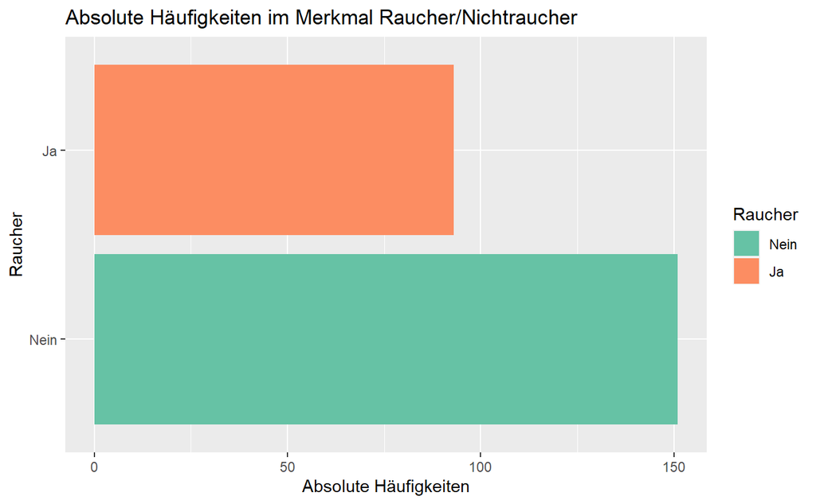

```r
# Und jetzt gleich noch ein ähnliches Balkendiagramm
# für Raucher und Wochentag
ggplot(daten) +
  geom_bar(mapping=aes(x=Raucher, fill=Raucher)) +
  scale_fill_brewer(palette="Set2") +
  labs(
    title="Absolute Häufigkeiten im Merkmal Raucher/Nichtraucher",
    x="Raucher",
    y="Absolute Häufigkeiten"
  )  +
 guides(fill=guide_legend(title="Raucher")) +
 coord_flip()

 ggsave(filename="tipsBarSmoker.png", plot=last_plot(),
       device="png",
       path="images/",
       width=16, height=9, units="cm")
```

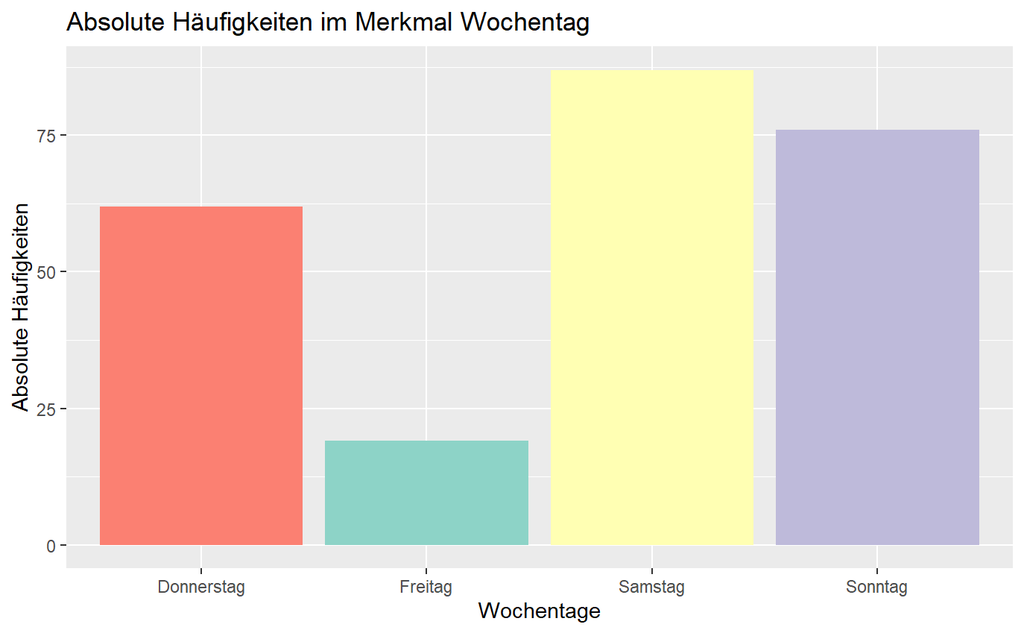

```r
# Wir müssen die Wochentage korrekt aufzählen,
# obwohl wir die Faktoren schon korrekt sortiert haben
ggplot(daten) +
  geom_bar(mapping=aes(x=Wochentag, fill=Wochentag)) +
  scale_fill_brewer(palette="Set3") +
  scale_x_discrete(limits=c("Donnerstag", "Freitag", "Samstag", "Sonntag"),
                   breaks = c("Donnerstag", "Freitag", "Samstag", "Sonntag")) +
  labs(
    title="Absolute Häufigkeiten im Merkmal Wochentag",
    x="Wochentage",
    y="Absolute Häufigkeiten"
  )  +
  theme(legend.position="none")
```

Statt der absoluten Häufigkeiten können wir natürlich auch relative Häufigkeiten darstellen. Das Balkendiagramm für die relative Häufigkeiten im Merkmal Geschlecht erhalten wir so:

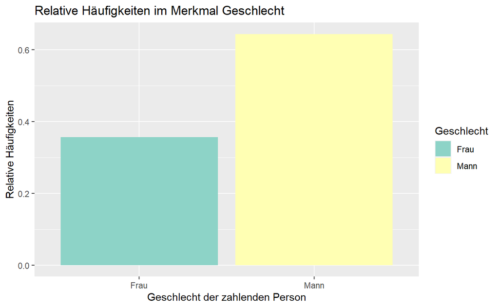

```r
balken <- ggplot(daten, aes(x=Geschlecht)) +
  geom_bar(mapping=aes(y = (..count..)/sum(..count..), fill=Geschlecht)) +
  scale_fill_brewer(palette="Set3") +
  labs(
    title="Relative Häufigkeiten im Merkmal Geschlecht",
    x="Geschlecht der zahlenden Person",
    y="Relative Häufigkeiten"
  )  +
 guides(fill=guide_legend(title="Geschlecht"))

balken
```

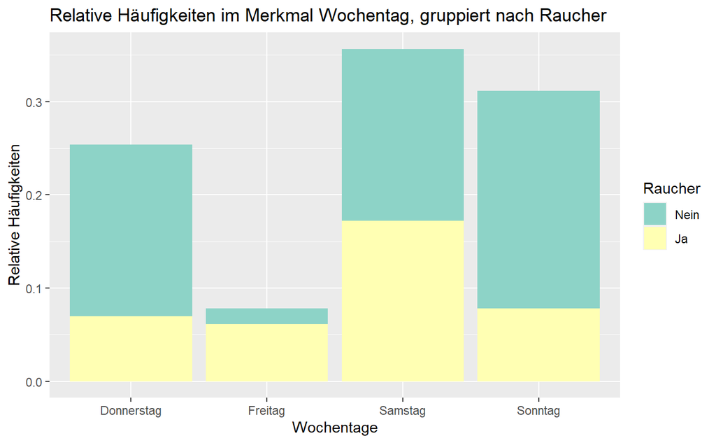

```r
# Wir färben die Tage nach Raucher
ggplot(daten) +
  geom_bar(mapping=aes(x=Wochentag, y = (..count..)/sum(..count..), fill=Raucher)) +
  scale_fill_brewer(palette="Set3") +
  scale_x_discrete(limits=c("Donnerstag", "Freitag", "Samstag", "Sonntag"),
                   breaks=c("Donnerstag", "Freitag", "Samstag", "Sonntag")) +
  labs(
    title="Relative Häufigkeiten im Merkmal Wochentag, gruppiert nach Raucher",
    x="Wochentage",
    y="Relative Häufigkeiten"
  )  +
  guides(fill=guide_legend(title="Raucher"))
```

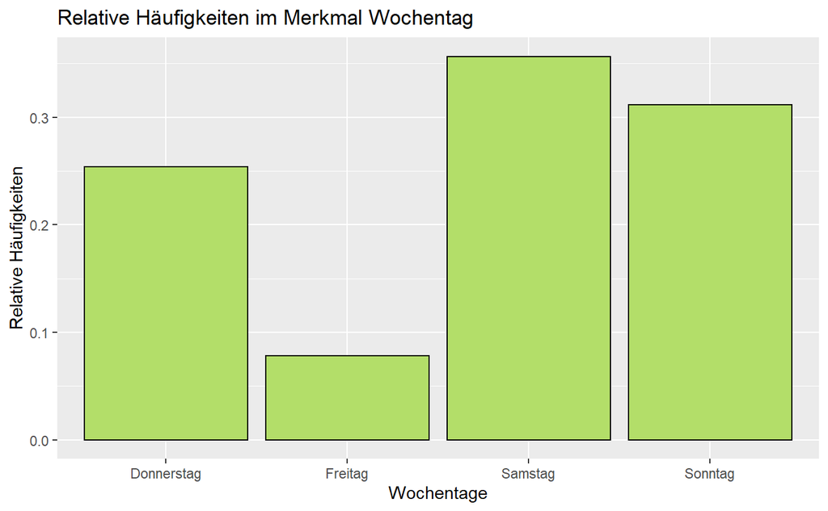

```r
ggplot(daten) +
  geom_bar(mapping=aes(x=Wochentag,
                       y = ..prop..,
                       group = 1),
           fill = myPalette[7],
           color="black"
           ) +
  scale_x_discrete(limits=c("Donnerstag", "Freitag", "Samstag", "Sonntag"),
                   breaks = c("Donnerstag", "Freitag", "Samstag", "Sonntag")) +
  labs(
    title="Relative Häufigkeiten im Merkmal Wochentag",
    x="Wochentage",
    y="Relative Häufigkeiten"
  )  +
  theme(legend.position="none")

 ggsave(filename="tipsBarDays.png", plot=last_plot(),
       device="png",
       path="images/",
       width=16, height=9, units="cm")
```

Jetzt erstellen wir Balkendiagramme, die wir mit Hilfe eines weiteren Merkmals färben.

```r
# Wir färben die Tage nach Raucher/Nichtraucher und erzeugen
# einen stacked bar plot
ggplot(daten) +
  geom_bar(mapping=aes(x=Wochentag, fill=Raucher)) +
  scale_fill_brewer(palette="Set3") +
  scale_x_discrete(limits=c("Donnerstag", "Freitag", "Samstag", "Sonntag")) +
  labs(
    title="Absolute Häufigkeiten im Merkmal Wochentag, gruppiert nach Raucher",
    x="Wochentage",
    y="Absolute Häufigkeiten"
  )  +
  guides(fill=guide_legend(title="Raucher"))

ggsave(filename="tipsDaysStackedColored.png", plot=last_plot(), device="png",
       path="images/", width=16, height=9, units="cm")

# Wir färben die Tage nach Raucher, ohne stacks
ggplot(daten) +
  geom_bar(mapping=aes(x=Wochentag, fill=Raucher), position="dodge") +
  scale_fill_brewer(palette="Set3") +
  scale_x_discrete(limits=c("Donnerstag", "Freitag", "Samstag", "Sonntag")) +
  labs(
    title="Absolute Häufigkeiten im Merkmal Wochentag, gruppiert nach Raucher",
    x="Wochentage",
    y="Absolute Häufigkeiten"
  )  +
  guides(fill=guide_legend(title="Raucher"))

ggsave(filename="tipsDaysDodgedColored.png", plot=last_plot(), device="png",
       path="images/", width=16, height=9, units="cm")
```

[output not shown]

Wir erstellen ein Radar-Chart für die wochentage.

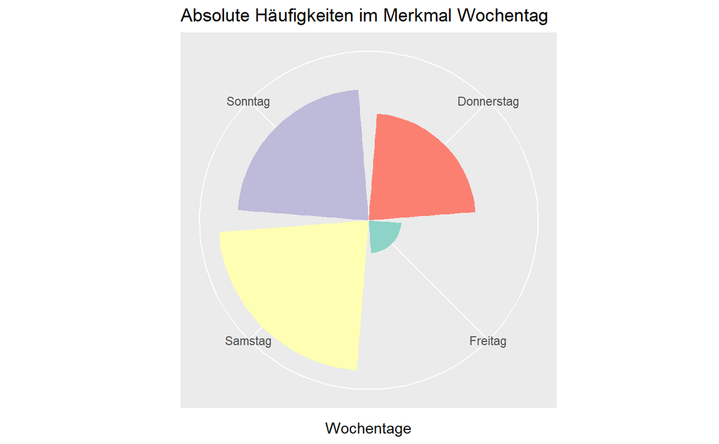

```r
# Polarkoordinaten erzeugen ein Polar Chart
ggplot(daten) +
  geom_bar(mapping=aes(x=Wochentag, fill=Wochentag)) +
  scale_fill_brewer(palette="Set3") +
  scale_x_discrete(limits=c("Donnerstag", "Freitag", "Samstag", "Sonntag")) +
  scale_y_discrete(breaks=NULL) + # keine Ticks
  labs(
    title="Absolute Häufigkeiten im Merkmal Wochentag",
    x="Wochentage",
    y = ""
  )  +
    theme(legend.position="none") +
  coord_polar()

ggsave(filename="tipsDaysRadar.png", plot=last_plot(), device="png",
       path="images/", width=16, height=9, units="cm")
```

## Histogramme

Wir erstellen Histogramme. Wir ersetzen *geom_bar* durch *geom_histrogram*. Die Klassenbreite ist mit Hilfe des Attributs *binwidth* einstellbar.

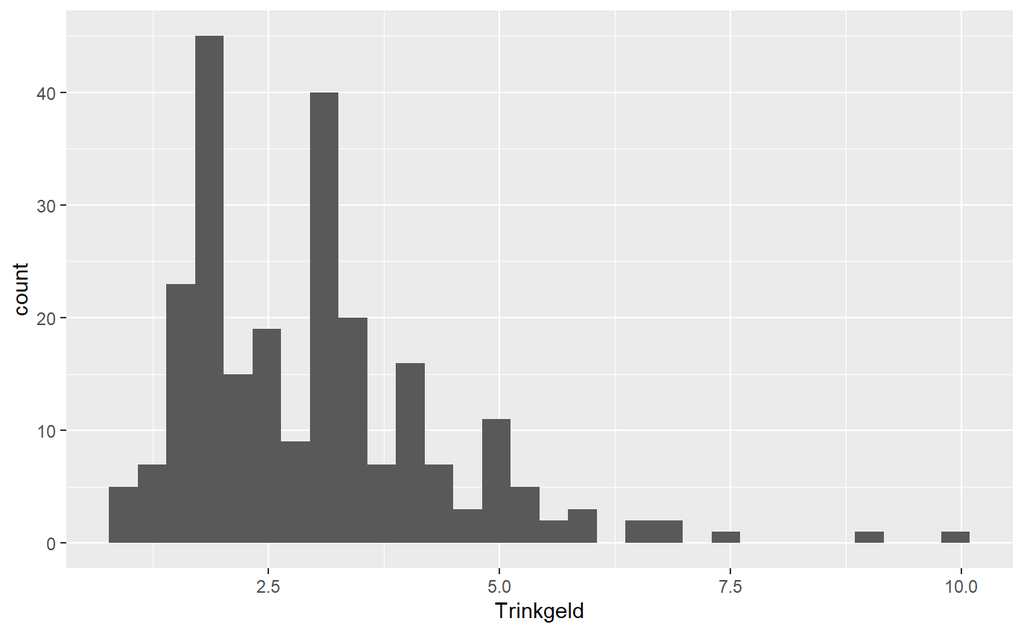

```r
# Alles als Default, ohne Farbe
# In ggplot ist der Default der Anzahl der Klassen 30
# Auf der Konsole kommt eine Warnung dazu.
ggplot(daten) +
  geom_histogram(mapping=aes(x=Trinkgeld))
```

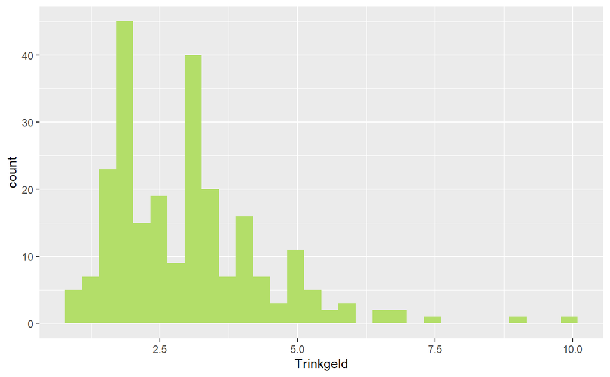

```r
# Mit einer Farbe
# Wir schalten die Legende ab
ggplot(daten) +
  geom_histogram(mapping=aes(x=Trinkgeld),
                 fill = myPalette[7],
                 show.legend=FALSE)
```

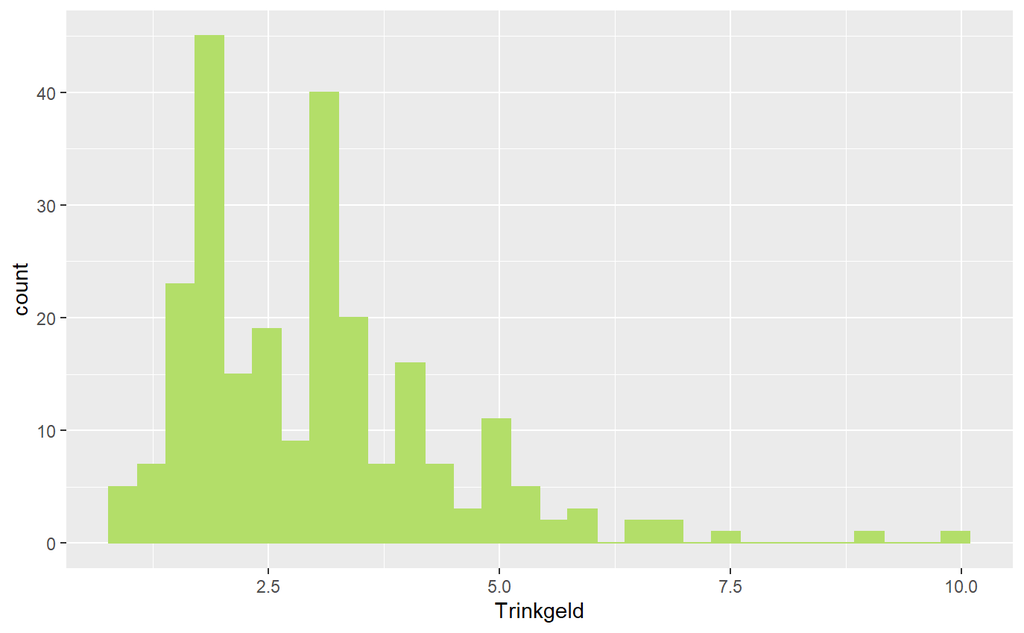

```r
# Farbe für das Füllen und den Rand
ggplot(daten) +
  geom_histogram(mapping=aes(x=Trinkgeld),
                 fill = myPalette[7],
                 color = myPalette[7],
                 show.legend=FALSE
                 )
```

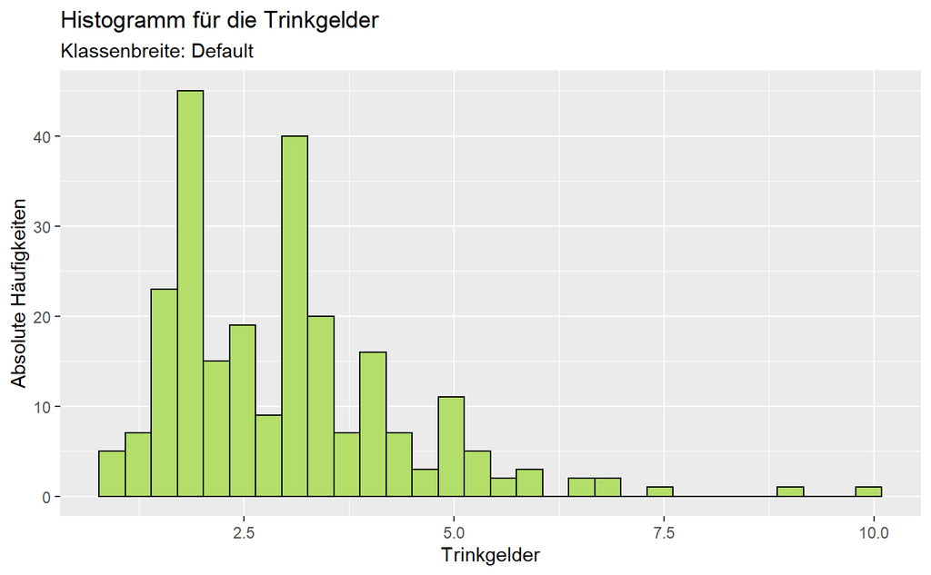

```r
ggplot(daten) +
  geom_histogram(mapping=aes(x=Trinkgeld),
                 fill = myPalette[7],
                 color = "black",
                 show.legend=FALSE) +
  labs(
    title="Histogramm für die Trinkgelder",
    subtitle="Klassenbreite: Default",
    x="Trinkgelder",
    y="Absolute Häufigkeiten"
  )
ggsave(filename="tipsHistoDefault.png", plot=last_plot(),
       device="png",
       path="images/",
       width=16,
       height=9,
       units="cm")
```

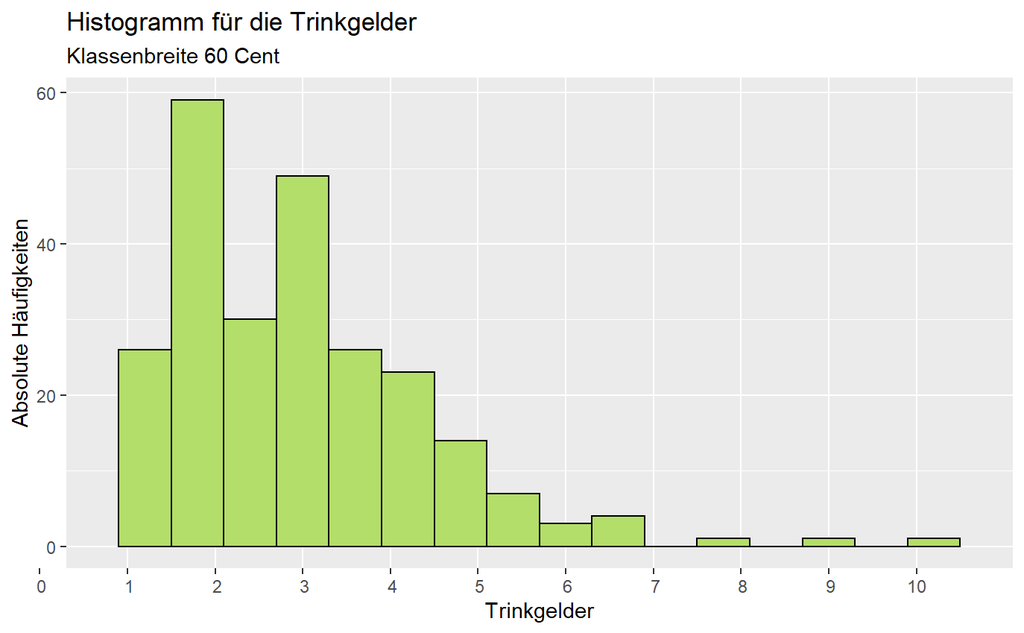

```r
ggplot(daten) +
  geom_histogram(mapping=aes(x=Trinkgeld),
                 fill = myPalette[7],
                 color = "black",
                 binwidth=0.6,
                 show.legend=FALSE) +
  scale_x_discrete(limits = seq(0.0, 10.5),
                   breaks = seq(0.0, 10.5)) +
  labs(
    title="Histogramm für die Trinkgelder",
    subtitle="Klassenbreite 60 Cent",
    x="Trinkgelder",
    y="Absolute Häufigkeiten"
  )
ggsave(filename="tipsHisto06.png", plot=last_plot(),
       device="png",
       path="images/",
       width=16,
       height=9,
       units="cm")
```

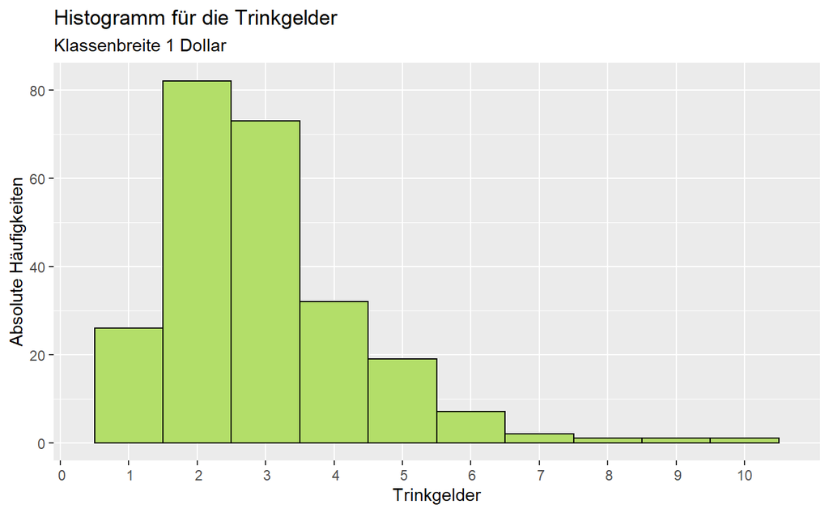

```r
ggplot(daten) +
  geom_histogram(mapping=aes(x=Trinkgeld),
                 fill = myPalette[7],
                 color = "black",
                 binwidth=1.0,
                 show.legend=FALSE) +
  scale_x_discrete(limits = seq(0.0, 10.5),
                   breaks = seq(0.0, 10.5)) +
  labs(
    title="Histogramm für die Trinkgelder",
    subtitle="Klassenbreite 1 Dollar",
    x="Trinkgelder",
    y="Absolute Häufigkeiten"
  )
ggsave(filename="tipsHisto10.png", plot=last_plot(),
       device="png",
       path="images/",
       width=16,
       height=9,
       units="cm")
```

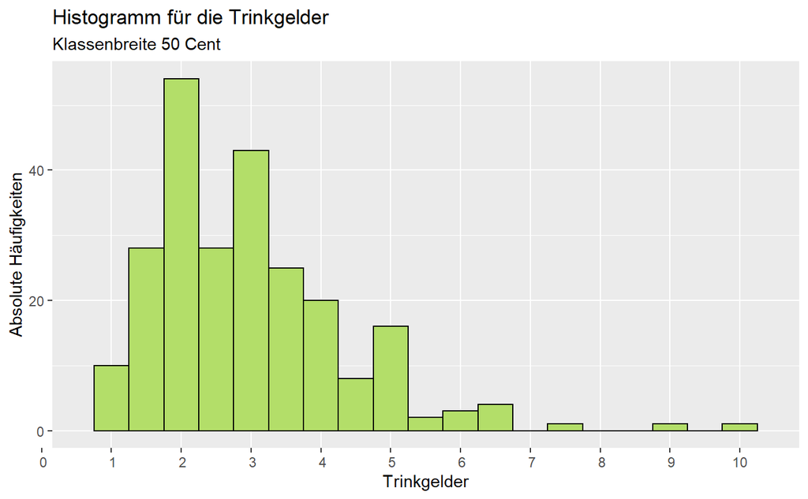

```r
ggplot(daten) +
  geom_histogram(mapping=aes(x=Trinkgeld),
                 fill = myPalette[7],
                 color = "black",
                 binwidth=0.5,
                 show.legend=FALSE) +
  scale_x_discrete(limits = seq(0.0, 10.5),
                   breaks = seq(0.0, 10.5)) +
  labs(
    title="Histogramm für die Trinkgelder",
    subtitle="Klassenbreite 50 Cent",
    x="Trinkgelder",
    y="Absolute Häufigkeiten"
  )
ggsave(filename="tipsHisto05.png", plot=last_plot(),
       device="png",
       path="images/",
       width=16,
       height=9,
       units="cm")
```

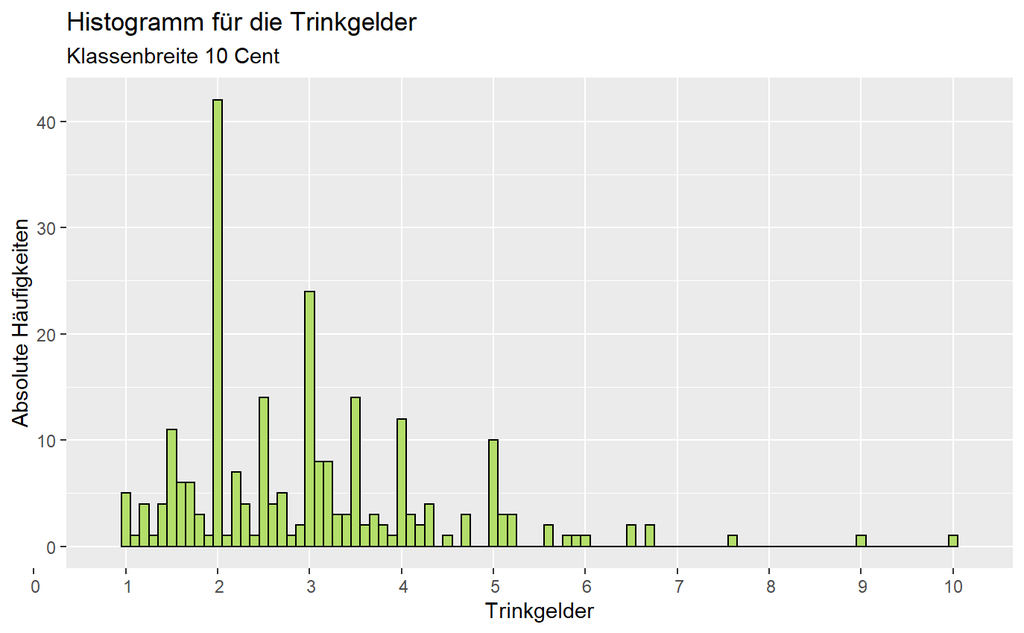

```r
ggplot(daten) +
  geom_histogram(mapping=aes(x=Trinkgeld),
                 fill = myPalette[7],
                 color = "black",
                 binwidth=0.1,
                 show.legend=FALSE) +
  scale_x_discrete(limits = seq(0.0, 10.5),
                   breaks = seq(0.0, 10.5)) +
  labs(
    title="Histogramm für die Trinkgelder",
    subtitle="Klassenbreite 10 Cent",
    x="Trinkgelder",
    y="Absolute Häufigkeiten"
  )
ggsave(filename="tipsHisto01.png", plot=last_plot(),
       device="png",
       path="images/",
       width=16,
       height=9,
       units="cm")
```

Auch hier können wir wieder die absoluten durch die relativen Häufigkeiten ersetzen:

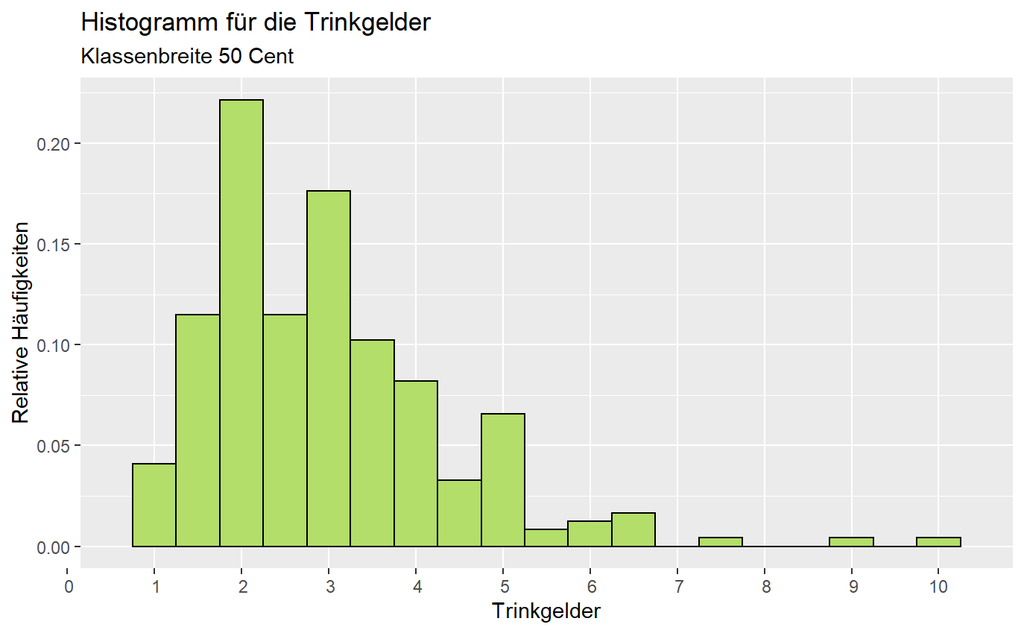

```r
ggplot(daten) +
  geom_histogram(mapping=aes(x=Trinkgeld,
                             y = (..count..)/sum(..count..)),
                 fill = myPalette[7],
                 color = "black",
                 binwidth=0.5, color="black",
                 show.legend=FALSE) +
  scale_x_discrete(limits = seq(0.0, 10.5),
                   breaks = seq(0.0, 10.5)) +
  labs(
    title="Histogramm für die Trinkgelder",
    subtitle="Klassenbreite 50 Cent",
    x="Trinkgelder",
    y="Relative Häufigkeiten"
  )
```

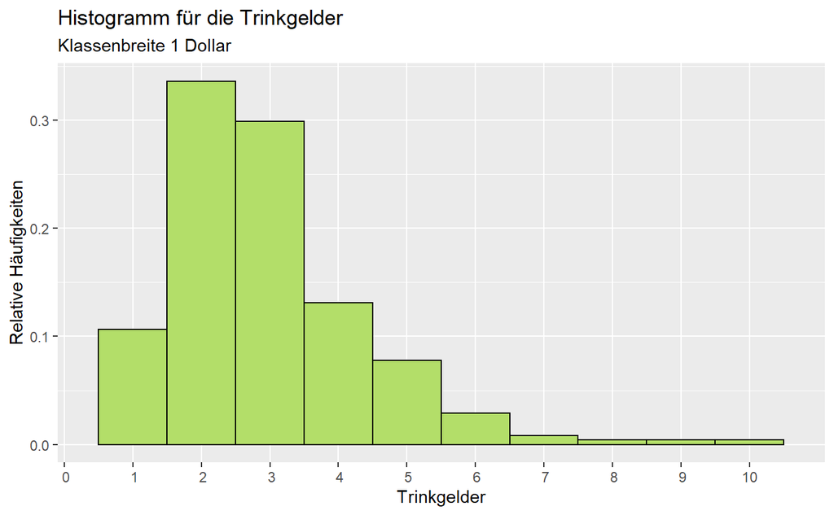

```r
ggplot(daten) +
  geom_histogram(mapping=aes(x=Trinkgeld,
                             y = (..count..)/sum(..count..)),
                 fill = myPalette[7],
                 color = "black",
                 binwidth=1.0,
                 show.legend=FALSE) +
  scale_x_discrete(limits = seq(0.0, 10.5),
                   breaks = seq(0.0, 10.5)) +
  labs(
    title="Histogramm für die Trinkgelder",
    subtitle="Klassenbreite 1 Dollar",
    x="Trinkgelder",
    y="Relative Häufigkeiten"
  )
```

## Boxplots

Boxplots erhalten wir mit Hilfe von *geom_boxplot*. Wie bei den Balkendiagrammen beginnen wir mit Default-Einstellungen und fügen sukzessive weitere Attribute in die grafischen Darstellungen ein.

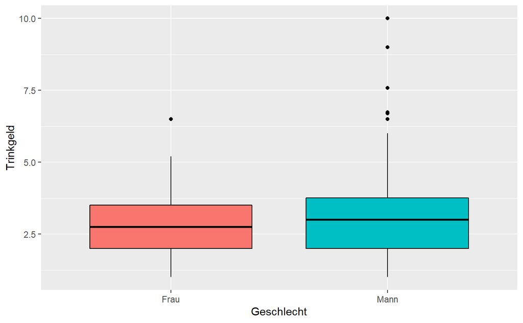

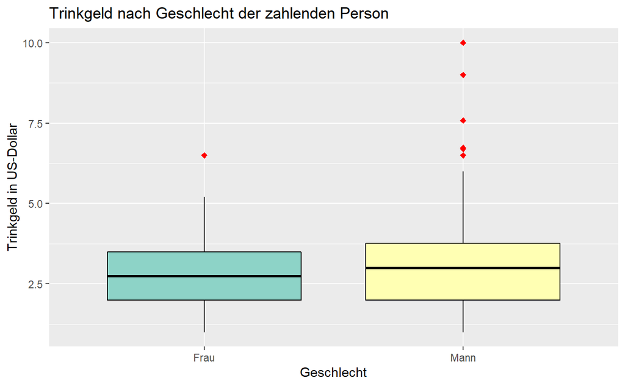

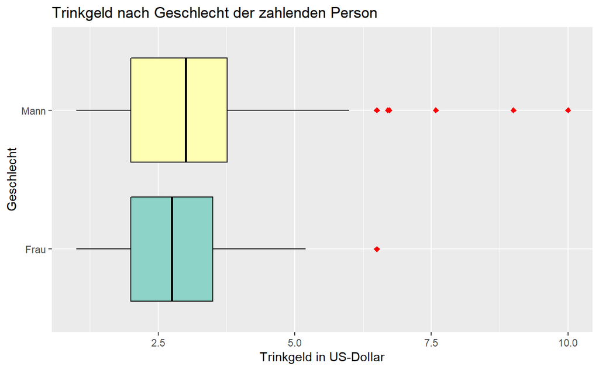

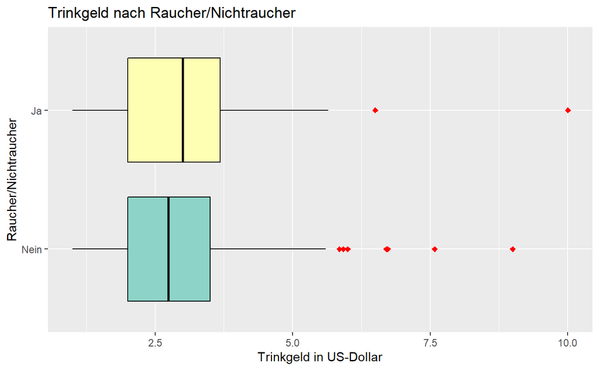

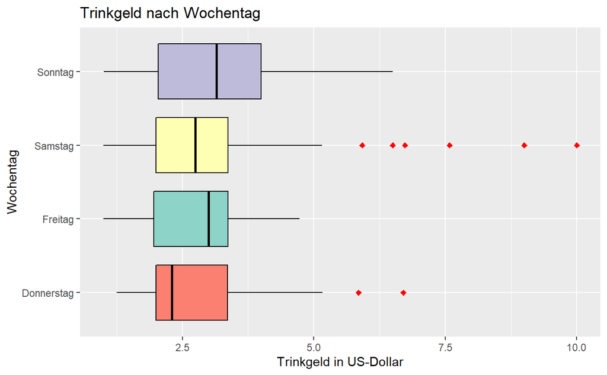

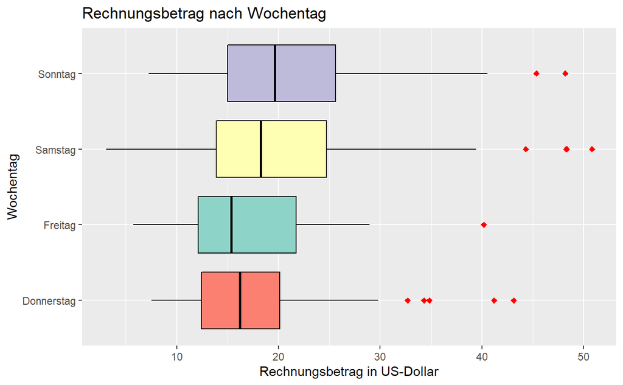

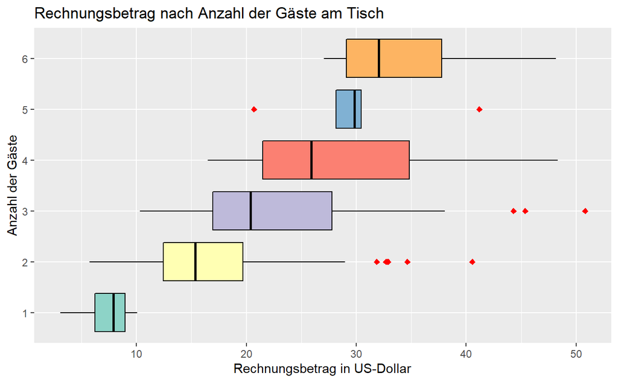

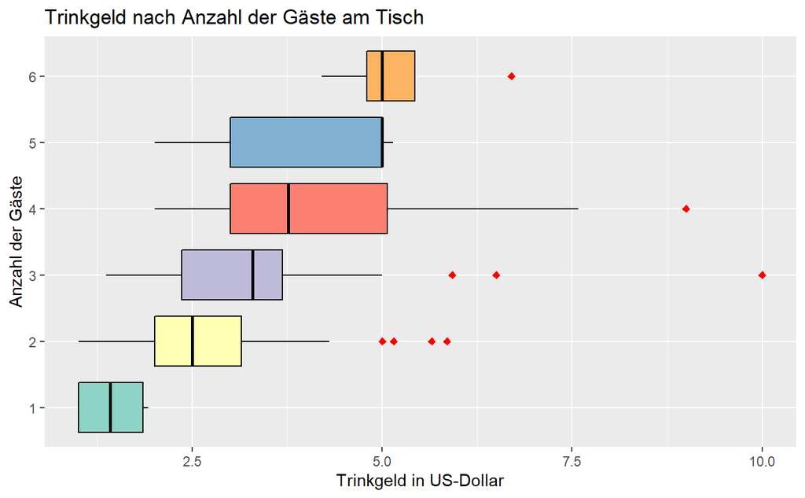